# Choice-Based Conjoint study

Hamza

# 1 Task 1

Read and inspect the data set. Provide a descriptive analysis for each of the variables in the data set. Make sure you provide an analysis that is meaningful for each variable type (e.g., factors, identifiers).

- **Anwser**

```r
# Load packages
library("plotly")
library("tidyverse")
library("data.table")
library("dplyr")
library("gridExtra")
library("knitr")
library("scales")
# Load Cloud Data
df.aal <- read_csv("cloud.csv")
# view first 6 rows of cloud.csv
head(df.aal)
```

```
## # A tibble: 6 x 9
##   respondent_id choiseset_id alternative_id choice_id cloud_storage
##           <dbl>        <dbl>          <dbl>     <dbl> <chr>
## 1             1            1              1         1 2000gb
## 2             1            1              2         1 5000gb
## 3             1            1              3         1 30gb
## 4             1            2              1         2 2000gb
## 5             1            2              2         2 5000gb
## 6             1            2              3         2 30gb
## # ... with 4 more variables: customer_support <chr>, cloud_services <chr>,
## #   price <chr>, choice <dbl>
```

```r
# reveal cloud.csv data analysis
str(df.aal)
```

```
## spec_tbl_df [9,000 x 9] (S3: spec_tbl_df/tbl_df/tbl/data.frame)
##  $ respondent_id   : num [1:9000] 1 1 1 1 1 1 1 1 1 1 ...
##  $ choiseset_id    : num [1:9000] 1 1 1 2 2 2 3 3 3 4 ...
##  $ alternative_id  : num [1:9000] 1 2 3 1 2 3 1 2 3 1 ...
##  $ choice_id       : num [1:9000] 1 1 1 2 2 2 3 3 3 4 ...
##  $ cloud_storage   : chr [1:9000] "2000gb" "5000gb" "30gb" "2000gb" ...
##  $ customer_support: chr [1:9000] "yes" "no" "yes" "no" ...
##  $ cloud_services  : chr [1:9000] "email" "email, video, productivity" "email" "email, video, productivity" ...
##  $ price           : chr [1:9000] "p18" "p6" "p18" "p18" ...
##  $ choice          : num [1:9000] 0 1 0 0 1 0 0 0 1 0 ...
##  - attr(*, "spec")=
##   .. cols(
##   ..   respondent_id = col_double(),
##   ..   choiseset_id = col_double(),
##   ..   alternative_id = col_double(),
##   ..   choice_id = col_double(),
##   ..   cloud_storage = col_character(),
##   ..   customer_support = col_character(),
##   ..   cloud_services = col_character(),
##   ..   price = col_character(),
##   ..   choice = col_double()
##   .. )
##  - attr(*, "problems")=<externalptr>
```

```r
# descriptive analysis of cloud.csv
summary(df.aal)
```

```
##  respondent_id     choiseset_id alternative_id   choice_id
##  Min.   :  1.00   Min.   : 1    Min.   :1      Min.   :   1.0
##  1st Qu.: 50.75   1st Qu.: 4    1st Qu.:1      1st Qu.: 750.8
##  Median :100.50   Median : 8    Median :2      Median :1500.5
##  Mean   :100.50   Mean   : 8    Mean   :2      Mean   :1500.5
##  3rd Qu.:150.25   3rd Qu.:12    3rd Qu.:3      3rd Qu.:2250.2
##  Max.   :200.00   Max.   :15    Max.   :3      Max.   :3000.0
##  cloud_storage      customer_support   cloud_services        price
##  Length:9000        Length:9000        Length:9000        Length:9000
##  Class :character   Class :character   Class :character   Class :character
##  Mode  :character   Mode  :character   Mode  :character   Mode  :character
##
##
##
##      choice
##  Min.   :0.0000
##  1st Qu.:0.0000
##  Median :0.0000
##  Mean   :0.3333
##  3rd Qu.:1.0000
##  Max.   :1.0000
```

running the str() function gives a quick description of cloud.csv. we have 9 Columns and 9000 attributes. we have 5 columns with Number data types or class , these columns are respondent_id , choiseset_id , alternative_id, choice_id, and choice we have 4 columns with character data type or class , these columns are cloud_storage , customer_support ,cloud_services , and price.

# 2 Task 2

Convert the attribute variables cloud_storage and price so that the factor reference levels are the levels representing the smallest values (i.e., 30GB for cloud_storage and p6 for price). Why there is no need to perform this step on the rest of the attribute variables?

- **Anwser**

```r
# convert cloud_storage as factors in order 30gb<200gb<5000gb
df.aal$cloud_storage <- as.factor(df.aal$cloud_storage)
# view of cloud_storage attributes
table(df.aal$cloud_storage)
```

```
##
## 2000gb   30gb 5000gb
##   3004   3003   2993
```

```r
# convert price as factors in order p6<p12<p18
df.aal$price <- as.factor(df.aal$price)
# view order of price
table(df.aal$price)
```

```
##
##  p12  p18   p6
## 2977 3023 3000
```

```r
df.aal$cloud_services <- as.factor(df.aal$cloud_services)
# view order of price
table(df.aal$cloud_services)
```

```
##
##                      email               email, video
##                       2999                       3001
## email, video, productivity
##                       3000
```

```r
df.aal$customer_support <- as.factor(df.aal$customer_support)
# view order of price
table(df.aal$customer_support)
```

```
##
##   no  yes
## 4525 4475
```

# 3 Task 3

Create a new variable in the data set that turns price into numeric class (do not overwrite price). Call this new variable price_n. What is the mean of variable price_n?

- **Anwser**

```r
# create a variable price_n as numberic
price_n <- as.numeric(df.aal$price)
# view or confirm conversion true
mean(price_n)
```

```
## [1] 2.002556
```

Mean of price_n = 2.002556

# 4 Task 4

There are 3000 choice sets in the data set. Therefore, there were 3000 choices made. Out of these 3000 choices, how many times did respondents choose a 30GB cloud storage? What is the percentage of respondents who chose email only as cloud service?

- **Anwser**

```r
# make a pie chart of storage in percentages
p <- df.aal %>% group_by(cloud_storage) %>% count(cloud_storage) %>% mutate( n=as.numeric(n))
head(p)
```

```
## # A tibble: 3 x 2
## # Groups:   cloud_storage [3]
##   cloud_storage     n
##   <fct>         <dbl>
## 1 2000gb         3004
## 2 30gb           3003
## 3 5000gb         2993
```

[figure not shown]

```r
perc = p$n/sum(p$n)
Labels = percent(perc)
pie(p$n,labels = Labels ,main = "Pie Chart Of Cloud Storage", col=c("lightblue","orange","brown"))
legend("topright", c("30gb","2000gb","5000gb"), cex = 0.8,fill = c("lightblue","orange","brown"))
```

```r
# make a pie chart of storage in percentages
q <- df.aal %>% group_by(cloud_services) %>% count(cloud_services) %>% mutate( n=as.numeric(n))
head(q)
```

```
## # A tibble: 3 x 2
## # Groups:   cloud_services [3]
##   cloud_services                 n
##   <fct>                      <dbl>
## 1 email                       2999
## 2 email, video                3001
## 3 email, video, productivity  3000
```

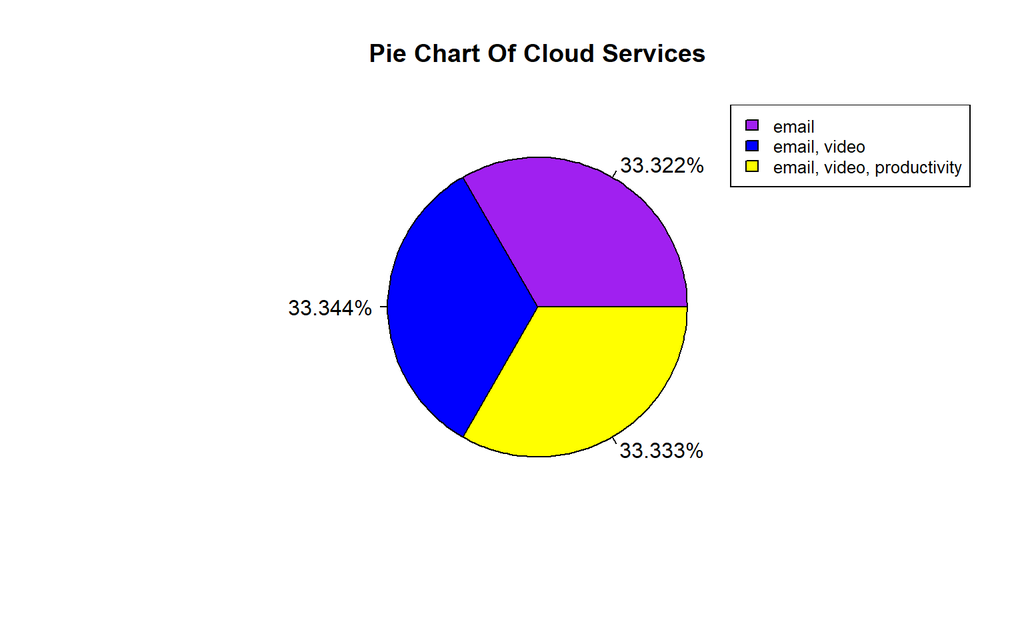

```r
perc = q$n/sum(q$n)
Labels = percent(perc)
pie(q$n,labels = Labels ,main = "Pie Chart Of Cloud Services", col=c("purple","blue","yellow"))
legend("topright", c("email","email, video","email, video, productivity"), cex = 0.8,fill = c("purple","blue","yellow"))
```

Email only as cloud service was 33.322%

# 5 Task 5

Use the dfidx() function from the dfidx package to create a specially formatted data object that will be used in the process of estimating a multinomial conjoint model. In the argument idx, use a list of the two indexes (choice_id and respondent_id) that define unique observations. Also use alternative_id as the variable defining the levels of the alternatives. Call this data object m_data. How many variables (i.e., columns) does m_data have?

- **Anwser**

```r
# load dfidx package
library("dfidx")
```

```r
# remove duplicated rows based on choice_id and respondent_id
z <- df.aal
z$choice <- as.logical(z$choice)
z$choice_id <- as.factor(z$choice_id)
z$customer_support <- as.factor(z$customer_support)
z$cloud_services <- as.factor(z$cloud_services)
# create formated data object _m_data
m_data <- dfidx(z, idx = list(c("choice_id", "respondent_id"), "alternative_id"),choice = "choice")
#
head(m_data)
```

```
## # A tibble: 9,000 x 7
##    choiseset_id cloud_storage customer_support cloud_services       price choice
##  *        <dbl> <fct>         <fct>            <fct>                <fct> <lgl>
##  1            1 2000gb        yes              email                p18   FALSE
##  2            1 5000gb        no               email, video, produ~ p6    TRUE
##  3            1 30gb          yes              email                p18   FALSE
##  4            2 2000gb        no               email, video, produ~ p18   FALSE
##  5            2 5000gb        yes              email                p6    TRUE
##  6            2 30gb          no               email                p18   FALSE
##  7            3 30gb          no               email                p12   FALSE
##  8            3 2000gb        yes              email, video         p12   FALSE
##  9            3 2000gb        no               email, video         p12   TRUE
## 10            4 30gb          yes              email                p12   FALSE
## # ... with 8,990 more rows, and 1 more variable: idx <idx[,3]>
##
## ~~~ indexes ~~~~
##    choice_id respondent_id alternative_id
## 1          1             1              1
## 2          1             1              2
## 3          1             1              3
## 4          2             1              1
## 5          2             1              2
## 6          2             1              3
## 7          3             1              1
## 8          3             1              2
## 9          3             1              3
## 10         4             1              1
## indexes:  1, 1, 2
```

m_data has 7 columns

# 6 Task 6

Use m_data to build a multinomial logit model that predicts choice from cloud_storage,customer_support,cloud_services, and price.Make sure that you tell the mlogit() function to exclude the intercept term. Call this model model1. Use set.seed(123) right before running the command that builds the model. Comment on the coefficient estimates of cloud_storage5000gb and pricep12.

- **Anwser**

```r
# load mlogit package
library("mlogit")
```

```r
# build multinomial logit model
model1 <- mlogit (choice ~ cloud_storage + customer_support + cloud_services + price | 0, data = m_data  , seed = 123  )
summary(model1)
```

```
##
## Call:
## mlogit(formula = choice ~ cloud_storage + customer_support +
##     cloud_services + price | 0, data = m_data, seed = 123, method = "nr")
##
## Frequencies of alternatives:choice
##     1     2     3
## 0.329 0.338 0.333
##
## nr method
## 5 iterations, 0h:0m:0s
## g'(-H)^-1g = 0.000101
## successive function values within tolerance limits
##
## Coefficients :
##                                           Estimate Std. Error  z-value
## cloud_storage30gb                        -0.165323   0.063785  -2.5919
## cloud_storage5000gb                       0.729560   0.061706  11.8231
## customer_supportyes                       0.493309   0.051708   9.5403
## cloud_servicesemail, video                0.632000   0.065736   9.6142
## cloud_servicesemail, video, productivity  1.490839   0.067121  22.2112
## pricep18                                 -0.764707   0.067026 -11.4090
## pricep6                                   0.836795   0.059963  13.9551
##                                           Pr(>|z|)
## cloud_storage30gb                         0.009545 **
## cloud_storage5000gb                      < 2.2e-16 ***
## customer_supportyes                      < 2.2e-16 ***
## cloud_servicesemail, video               < 2.2e-16 ***
## cloud_servicesemail, video, productivity < 2.2e-16 ***
## pricep18                                 < 2.2e-16 ***
## pricep6                                  < 2.2e-16 ***
## ---
## Signif. codes:  0 '***' 0.001 '**' 0.01 '*' 0.05 '.' 0.1 ' ' 1
##
## Log-Likelihood: -2567.8
```

cloud_storage5000gb = 0.729560 this means the price is relevant and is the most favorable and choosen choice in storage pricep12 is the reference price

# 7 Task 7

Now follow the same process as in Task 6 to build a multinomial logit model that uses price_n instead of price. Call this model model2. Again use set.seed(123) right before running the command that builds the model. Comment on the coefficient estimate of price_n. What does this mean?

- **Anwser**

```r
# change column price to price_n
m_data3<-mutate(m_data,price = price_n)
# build multinomial logit model
model2 <- mlogit (choice ~ cloud_storage + customer_support + cloud_services + price_n  | 0 , data = m_data3 , seed = 123,)
summary(model2)
```

```
##
## Call:
## mlogit(formula = choice ~ cloud_storage + customer_support +
##     cloud_services + price_n | 0, data = m_data3, seed = 123,
##     method = "nr")
##
## Frequencies of alternatives:choice
##     1     2     3
## 0.329 0.338 0.333
##
## nr method
## 4 iterations, 0h:0m:0s
## g'(-H)^-1g = 7.27E-07
## gradient close to zero
##
## Coefficients :
##                                           Estimate Std. Error z-value Pr(>|z|)
## cloud_storage30gb                        -0.132103   0.061076 -2.1629  0.03055
## cloud_storage5000gb                       0.672351   0.058861 11.4226  < 2e-16
## customer_supportyes                       0.440922   0.049067  8.9861  < 2e-16
## cloud_servicesemail, video                0.584129   0.063133  9.2523  < 2e-16
## cloud_servicesemail, video, productivity  1.383752   0.063614 21.7523  < 2e-16
## price_n                                   0.442463   0.030360 14.5737  < 2e-16
##
## cloud_storage30gb                        *
## cloud_storage5000gb                      ***
## customer_supportyes                      ***
## cloud_servicesemail, video               ***
## cloud_servicesemail, video, productivity ***
## price_n                                  ***
## ---
## Signif. codes:  0 '***' 0.001 '**' 0.01 '*' 0.05 '.' 0.1 ' ' 1
##
## Log-Likelihood: -2791.6
```

# 8 Task 8

Use a likelihood ratio test to test the model2 against model1. What is the outcome of the test? Are model2 and model1 significantly different?Which model we should choose between the two and for what reason(s)?

- **Anwser**

```r
library(lmtest)
# perform likelihood ratio test for differences in models
lrtest(model1, model2)
```

```
## Likelihood ratio test
##
## Model 1: choice ~ cloud_storage + customer_support + cloud_services +
##     price | 0
## Model 2: choice ~ cloud_storage + customer_support + cloud_services +
##     price_n | 0
##   #Df  LogLik Df  Chisq Pr(>Chisq)
## 1   7 -2567.8
## 2   6 -2791.6 -1 447.68  < 2.2e-16 ***
## ---
## Signif. codes:  0 '***' 0.001 '**' 0.01 '*' 0.05 '.' 0.1 ' ' 1
```

# 9 Task 9

Use model2 to predict the choice probabilities for different alternatives in the data. What is the predicted probability of choosing the third alternative in the first choice set?

- **Anwser**

```r
# mode2
predicted_alt <- predict(model2, m_data3)
head(predicted_alt)
```

```
##           1         2          3
## 1 0.1030529 0.8066470 0.09030016
## 2 0.4154068 0.4933614 0.09123180
## 3 0.1605762 0.5107714 0.32865236
## 4 0.1539164 0.3951398 0.45094378
## 5 0.4765144 0.3852619 0.13822365
## 6 0.1585595 0.6326274 0.20881316
```

# 10 Task 10

Use the predicted probabilities from Task 9 to compute the predicted alternatives using the maximum choice probabilities. Which is the predicted alternative in the third choice set?

- **Anwser**

```r
head(summary(predicted_alt))
```

```
##        1                 2                 3
##  Min.   :0.02027   Min.   :0.02518   Min.   :0.02515
##  1st Qu.:0.17107   1st Qu.:0.18455   1st Qu.:0.17483
##  Median :0.28927   Median :0.30857   Median :0.30026
##  Mean   :0.32360   Mean   :0.34125   Mean   :0.33515
##  3rd Qu.:0.45122   3rd Qu.:0.48000   3rd Qu.:0.47257
##  Max.   :0.90985   Max.   :0.92932   Max.   :0.92926
```

# 11 Task 11

Then we can extract the selected alternatives from the original data. Which is the selected alternative in the fifteenth choice set?

- **Anwser**

```r
# call from row 15
head(m_data[15,])
```

```
## # A tibble: 1 x 7
##   choiseset_id cloud_storage customer_support cloud_services price choice
## *        <dbl> <fct>         <fct>            <fct>          <fct> <lgl>
## 1            5 5000gb        no               email          p12   FALSE
## # ... with 1 more variable: idx <idx[,3]>
##
## ~~~ indexes ~~~~
##   choice_id respondent_id alternative_id
## 1         5             1              3
## indexes:  1, 1, 2
```

Give Above in the code execution

# 12 Task 12

Compute the confusion matrix for model2. What is the accuracy (or hit rate) of model2? How does model2 compare to the baseline method (i.e., making random predictions)?

- **Anwser**

```r
# compute confussion matrix of model2
tab = table(predicted_alt>0.5,m_data3$choice)
tab
```

```
##
##         FALSE TRUE
##   FALSE  4744 2352
##   TRUE   1256  648
```

```r
#compute accuracy of model2
accurracy <- sum(diag(tab))/sum(tab)*100
accurracy
```

```
## [1] 59.91111
```

```r
# load package if required
library(ggpubr)
library(CGPfunctions)
# compute r model
```

# 13 Task 13

Now let us see how we can use the model2 parameters to predict market shares under hypothetical market scenarios for an arbitrary set of products. First, build a custom function to predict market share for an arbitrary set of alternatives available in a data set d. You can find the commands for building the custom function in the “Multinomial Choice Modelling Practical”. Call the custom function predict.share.

- **Anwser**

```r
products <- select(z,-c(respondent_id,choice))
predict.share <- function(model2,products) {
x <- predict(model2, products)
share <- matrix(x,dimnames=list(t(outer(colnames(x),rownames(x),FUN=paste)),NULL))
shares <- cbind(share, products)
return(shares)
}
```

# 14 Task 14

Create a data object (i.e., data.frame or tibble) with the following hypothetical market consisting of five alternatives: Call this data object d_base.

- **Anwser**

```r
cloud_storage <- c("30gb","30gb","30gb","5000gb","5000gb")
customer_support <- c("no","no","yes","yes","no")
cloud_services <- c("email","email,video","email","email","email,video,productivity")
price_n   <- c("6","12","12","18","18")
d_base <- data.frame(cloud_storage,customer_support,cloud_services,price_n)
head(d_base)
```

```
##   cloud_storage customer_support           cloud_services price_n
## 1          30gb               no                    email       6
## 2          30gb               no              email,video      12
## 3          30gb              yes                    email      12
## 4        5000gb              yes                    email      18
## 5        5000gb               no email,video,productivity      18
```

# 15 Task 15

Run the customer function predict.share using model2 and d_base as input arguments. What is the predicted market share for alternative four of this hypothetical market?

- **Anwser**

```r
d_base[nrow(d_base)+8995,] <- NA
head(predict.share(model2,d_base))
```

```
##       share cloud_storage customer_support           cloud_services price_n
## 1 0.3070386          30gb               no                    email       6
## 2 0.5220413          30gb               no              email,video      12
## 3 0.3065658          30gb              yes                    email      12
## 4 0.4779587        5000gb              yes                    email      18
## 5 0.3863956        5000gb               no email,video,productivity      18
## 6 0.0000000          <NA>             <NA>                     <NA>    <NA>
```

# 16 Task 16

Now consider a modification on the previous hypothetical market, in which the level of the cloud_services attribute changes for the fifth alternative to “email, video”. What is the predicted market share for alternative four of this new hypothetical market?

- **Anwser**

```r
cloud_storage <- c("30gb","30gb","30gb","5000gb","5000gb")
customer_support <- c("no","no","yes","yes","no")
cloud_services <- c("email","email,video","email","email","email, video")
price_n   <- c("6","12","12","18","18")
d_base1 <- data.frame(cloud_storage,customer_support,cloud_services,price_n)
head(d_base1)
```

```
##   cloud_storage customer_support cloud_services price_n
## 1          30gb               no          email       6
## 2          30gb               no    email,video      12
## 3          30gb              yes          email      12
## 4        5000gb              yes          email      18
## 5        5000gb               no   email, video      18
```

# 17 Task 17

Which alternative was affected the most from this modification of the hypothetical market, and by how much (in percentage terms)?

- **Anwser**

```r
d_base1[nrow(d_base1)+8995,] <- NA
head(predict.share(model2,d_base1))
```

```
##       share cloud_storage customer_support cloud_services price_n
## 1 0.2931992          30gb               no          email       6
## 2 0.5576005          30gb               no    email,video      12
## 3 0.3378216          30gb              yes          email      12
## 4 0.4423995        5000gb              yes          email      18
## 5 0.3689792        5000gb               no   email, video      18
## 6 0.0000000          <NA>             <NA>           <NA>    <NA>
```

# 18 Task 18

Use the model2 coefficients to calculate how much a consumer would be willing to pay (in £ per month) for customer support.

- **Anwser**

```r
print(coef(model2)[3]/coef(model2)[6])
```

```
## customer_supportyes
##           0.9965168
```

# 19 Task 19

Use the model2 coefficients to calculate how much a consumer would be willing to pay (in £ per month) for an upgrade from 30GB to 2000GB cloud storage.

- **Anwser**

```r
print(coef(model2)[1]/coef(model2)[6])
```

```
## cloud_storage30gb
##        -0.2985629
```

# 20 Task 20

Use the model2 coefficients to calculate how much a consumer would be willing to pay (in £ per month) for an upgrade from 2000GB to 5000GB cloud storage.

- **Anwser**

```r
print(coef(model2)[2]/coef(model2)[6])
```

```
## cloud_storage5000gb
##            1.519565
```